# Precipitation Evaluation

Arezoo Rafieeinasab

8/30/2017

# Background

Forcing could be stored in multiple files, either in input forcing files (such as *LDASIN* or *PRECIP_FORCING* files) or in the output files (*LDASOUT*). *LDASOUT* files may contain a variable called *ACCPRCP* storing the accumulated precipitation, and the rainfall depth can be obtained by subtracting two consecutive time steps. *LDASIN* and *PRECIP_FORCING* files store rain rate in *RAINRATE* and *precip_rate* variables, respectively. This vignette serves as a short explanation on how to retrieve data and perform some basic comparisons between two sets of data.

Load rwrfhydro package.

```r
> library(rwrfhydro)
```

# Import observed datasets

rwrfhydro provides few functions to retrieve observations from several networks. GHCN-Daily and USCRN networks are discussed below.

# USCRN

The US Climate Reference Network (USCRN) is a network of monitoring stations equipped with research quality instruments. Beside precipitation, these gauges report temperature, soil moisture and soil temperature. The precipitation is measured every 5 minutes using three independent measurements in a weighing bucket gauge accompanied with a disdrometer reporting the presence or absence of precipitation. These gauges, in the cold climate, are equipped with heating tape around the throat of the weighing gauge to prevent the frozen precipitation from accumulating on the interior walls and capping the gauge. The redundancy in the measurements is to ensure the quality of the measurements.

Data is provided in 4 different temporal resolution (subhourly, hourly, daily and monthly), and depending on the temporal resolution, the variables provided change. For more information on the data and how to retrieve, refer to the man page of `Get_USCRN`.

# GHCN-daily

Global Historical Climatology Network-Daily (GHCN-D) dataset contains daily data from around 80000 surface station in the world, which about two third of them are precipitation only (Menne et al. 2012). It is the most complete collection of U.S. daily data available (Menne et al. 2012). The dataset undergo an automated quality assurance which the details can be found in Durre et al. 2008; 2010. Data is available on http://www1.ncdc.noaa.gov/pub/data/ghcn/daily and is updated frequently. Data is available in two formats either categorized by gauge station or categorized by year. Accordingly, there are two functions to pull GHCN-daily data from these two sources called `GetGhcn` and `GetGhcn2`.

## Gauge selection

First step is to select the gauges you want to use for verification based on some criteria. GHCN-daily contains precipitation data from different sources such as COOP or CoCoRaHS. The selection criteria can be country code, states if country is US, type of rain gauge network (for example CoCoRaHS), or a rectangle domain.

```r
> #setInternet2(use=FALSE) # If using windows, you may need this.
>
> # Return all the gauges within US from observation network of COOP (C) and CoCoRaHS (1)
> countryCodeList <- c("US")
> networkCodeList <- c("1","C")
> sg <- SelectGhcnGauges(countryCode=countryCodeList,
+                        networkCode=networkCodeList)
> str(sg)
```

The `sg` dataframe has all the information provided by NCDC about each gauge. For the rest of this vignette we will use only the domain of Front Range which is the case study provided. We use the rectangle domain which is smaller than Front Range domian (for efficiency), as the boundary to collect all the gauges’ information.

```r
> sg <- SelectGhcnGauges(domain = TRUE, networkCode = "C", minLat = 39.5, maxLat = 40,
+                        minLon = -106.0, maxLon=-105)
> str(sg)
```

```
'data.frame':   31 obs. of  12 variables:
 $ country    : chr  "US" "US" "US" "US" ...
 $ network    : chr  "C" "C" "C" "C" ...
 $ stationID  : chr  "00050674" "00050848" "00051186" "00051681" ...
 $ latitude   : num  39.8 40 39.7 39.9 39.5 ...
 $ longitude  : num  -106 -105 -106 -105 -105 ...
 $ elevation  : num  3448 1672 3054 2728 2896 ...
 $ state      : chr  "CO" "CO" "CO" "CO" ...
 $ name       : chr  "BERTHOUD PASS                 " "BOULDER                       " "CABIN CREEK                   " "COAL CREEK CANYON             " ...
 $ GSNflag    : chr  "   " "   " "   " "   " ...
 $ HCN/CRNflag: chr  "   " "HCN" "   " "   " ...
 $ WMOID      : chr  "    " "    " "    " "    " ...
 $ siteIds    : chr  "USC00050674" "USC00050848" "USC00051186" "USC00051681" ...
```

## GetGhcn

GHCN-daily data are archived for each individual gauge in a text file in [here](http://www1.ncdc.noaa.gov/pub/data/ghcn/daily/all/). Precipitating can be downloaded for a single site or multiple ones by setting element to “PRCP” and specifying the desired start and end dates. Notice, precipitation values are converted from 10th of mm to mm.

```r
> startDate <- "2013/06/01"
> endDate <- "2013/07/01"
> element <- "PRCP"
> obsPrcp <- GetGhcn(sg$siteId, element, startDate, endDate, parallel = FALSE)
> str(obsPrcp)
```

```
'data.frame':   496 obs. of  5 variables:
 $ siteIds  : chr  "USC00050848" "USC00050848" "USC00050848" "USC00050848" ...
 $ Date     : Date, format: "2013-06-01" "2013-07-01" ...
 $ dailyGhcn: num  0 0 0 0 0 3 0 0 0 0 ...
 $ qFlag    : chr  NA NA NA NA ...
 $ element  : chr  "PRCP" "PRCP" "PRCP" "PRCP" ...
```

## GetGhcn2

NCDC also provides GHCN-daily categorized by year [here](http://www1.ncdc.noaa.gov/pub/data/ghcn/daily/by_year/). If the number of the gauges is big, `GetGhcn2` would be a much faster option to retrieve data. It has the same arguments as `GetGhcn`.

# Import forcing/precipitation data used in NWM

Forcing data used in WRF-Hydro modeling are usually stored in forcing files (such as `LDASIN` or `PRECIP_FORCING` files). Here we are going to use the data provided by the “Front Range” case study.

Set the path to the Front Range test case.

```r
> fcPath <- 'C:/Users/arezoo/Desktop/training'
> #fcPath <- '/glade2/scratch2/adugger/code_tests/FrnRngTestCase/Run.Reach2_spinup/FORCING'
```

First list of all the forcing files.

```r
> forcingPath <- paste0(fcPath,"/FORCING")
> files <- list.files(path = forcingPath, full.names = TRUE, pattern = glob2rx("201306*LDASIN_DOMAIN1"))
```

```r
> geoFile <- paste0(fcPath,'/DOMAIN/geo_em.nc')
> rainGaugeInds <- GetGeogridIndex(xy = data.frame(lon=sg$longitude, lat=sg$latitude),
+                                   ncfile = geoFile)
> sg <- cbind(sg,rainGaugeInds)
> head(sg)
```

```
      country network stationID latitude longitude elevation state
79198      US       C  00050674  39.8000 -105.7833    3448.2    CO
79214      US       C  00050848  39.9919 -105.2667    1671.5    CO
79233      US       C  00051186  39.6553 -105.7089    3054.1    CO
79253      US       C  00051681  39.8958 -105.3847    2728.0    CO
79269      US       C  00051829  39.5250 -105.3631    2895.6    CO
79294      US       C  00052223  39.7294 -105.0083    1593.5    CO
                                name GSNflag HCN/CRNflag WMOID     siteIds
79198 BERTHOUD PASS                                            USC00050674
79214 BOULDER                                        HCN       USC00050848
79233 CABIN CREEK                                              USC00051186
79253 COAL CREEK CANYON                                        USC00051681
79269 CONIFER 8 W                                              USC00051829
79294 DENVER WATER DEPT                                        USC00052223
       we  sn
79198 100 205
79214 144 221
79233 104 189
79253 134 212
79269 131 172
79294 163 191
```

Time to pull data from the files. One way is to use the `GetMultiNcdf` function in rwrfhydro. You need to prepare the file, var, and ind variables for `GetMultiNcdf` function (refer to Collect Output Data: GetMultiNcdf vignette). You can leave the stat as mean; since you are pulling data for a single pixel.

```r
> flList <- list(forcing = files)
> varList <- list(forcing = list(PRCP = 'RAINRATE'))
> prcpIndex <- list()
> for (i in 1:length(sg$siteIds)) {
+   if (!is.na(sg$we[i]) & !is.na(sg$sn[i])) {
+     prcpIndex[[as.character(sg$siteIds[i])]] <- list(start=c(sg$we[i], sg$sn[i],1),
+                                                      end=c(sg$we[i], sg$sn[i],1), stat="mean")
+   }
+ }
> indList <-list(forcing = list(PRCP = prcpIndex))
> prcpData <- GetMultiNcdf(file = flList, var = varList, ind = indList, parallel=FALSE)
> head(prcpData)
```

```
     POSIXct                inds stat     statArg variable        value
1 2013-06-01 100:100,205:205,1:1 mean USC00050674 RAINRATE 0.000000e+00
2 2013-06-01 144:144,221:221,1:1 mean USC00050848 RAINRATE 0.000000e+00
3 2013-06-01 104:104,189:189,1:1 mean USC00051186 RAINRATE 0.000000e+00
4 2013-06-01 134:134,212:212,1:1 mean USC00051681 RAINRATE 3.787151e-09
5 2013-06-01 131:131,172:172,1:1 mean USC00051829 RAINRATE 0.000000e+00
6 2013-06-01 163:163,191:191,1:1 mean USC00052223 RAINRATE 0.000000e+00
  variableGroup fileGroup
1          PRCP   forcing
2          PRCP   forcing
3          PRCP   forcing
4          PRCP   forcing
5          PRCP   forcing
6          PRCP   forcing
```

`GetMultiNcdf` pulls the time information from the netcdf files, if the data is not prepared properly, and the time info is not available, it will return the name of the file instead. In that case, time should be retrieved from the file name which is saved in column `POSIXct`. Since the `obsPrcp` data are in mm, we also convert the rainrate to rain depth in mm.

```r
> prcpData$value <- prcpData$value*3600
```

## Aggregating hourly data into daily.

Each GHCN gauge has a unique reporting time which the daily data is been calculated based on that. The reporting time is archived in the csv files and is retrieved when calling `GetGhcn2` function (you will not get the reporting time using `GetGhcn`). We need to add the reporting time for each point which would be the base for daily aggregation. If there will not be any `reportTime` in `sg` columns, then it uses the default which is 0700 AM.

```r
> if ("reportTime" %in% names(prcpData)) {
+   sg$reportTime <- obsPrcp$reportTime[match(sg$siteIds, obsPrcp$siteIds)]
+   sg$reportTime[which (sg$reportTime=="" | is.na(sg$reportTime))] <-700
+ }else{
+   sg$reportTime<- 700
+ }
```

Call the `CalcDailyGhcn` to convert the hourly data (model input) to daily data compatible with GHCN-Daily data. This function takes the following steps:

1. It first searches for a field called `timeZone` in the `sg` (selected gauges) dataframe. If the time zone does not exists, it will call `GetTimeZone(sg)` to add the time zone information. `sg` requires at least two fields of `latitude` and `longitude` so that `GetTimeZone` works.
2. After adding time zone for each gauge, the time offset will be added from the `tzLookup` data provided in rwrfhydro. The time offset is used to convert UTC time to Local Standard Time (LST) since the GHCN-D is reported in LST.
3. Then it aggregates the hourly precipitation to daily based on the reporting time of individual gauges and return the `dailyData`. `numberOfDataPoints` column has the number of hours with observations in a day so you can remove days without complete record.

```r
> names(prcpData)[names(prcpData) == 'value'] <- 'DEL_ACCPRCP'
> dailyData <- CalcDailyGhcn(sg = sg,prcp = prcpData)
> head(dailyData)
```

```
     ghcnDay     statArg    dailyPrcp numberOfDataPoints
1 2013-06-01 USC00050674 0.1408545038                 15
2 2013-06-01 USC00050848 0.0000000000                 15
3 2013-06-01 USC00051186 0.0000000000                 15
4 2013-06-01 USC00051681 0.0008998272                 15
5 2013-06-01 USC00051829 0.0000000000                 15
6 2013-06-01 USC00052223 0.0133403056                 15
```

## Comparing daily QPE/QPF versus GHCN-D

Final step if to find the common data between the two dataset (precipitation time series (`dailyData`) and the observed GHCN-D (`obsPrcp`)). If you have a big dataset, it is recommended to use data.table instead of data.frame which is incredibly faster.

```r
> str(obsPrcp)
```

```
'data.frame':   496 obs. of  5 variables:
 $ siteIds  : chr  "USC00050848" "USC00050848" "USC00050848" "USC00050848" ...
 $ Date     : Date, format: "2013-06-01" "2013-07-01" ...
 $ dailyGhcn: num  0 0 0 0 0 3 0 0 0 0 ...
 $ qFlag    : chr  NA NA NA NA ...
 $ element  : chr  "PRCP" "PRCP" "PRCP" "PRCP" ...
```

```r
> str(dailyData)
```

```
'data.frame':   961 obs. of  4 variables:
 $ ghcnDay           : Date, format: "2013-06-01" "2013-06-01" ...
 $ statArg           : chr  "USC00050674" "USC00050848" "USC00051186" "USC00051681" ...
 $ dailyPrcp         : num  0.1409 0 0 0.0009 0 ...
 $ numberOfDataPoints: int  15 15 15 15 15 15 15 15 15 15 ...
```

```r
> common <- merge(dailyData, obsPrcp,
+                 by.x=c("ghcnDay","statArg"),
+                 by.y=c("Date","siteIds"))
> head(common)
```

```
     ghcnDay     statArg    dailyPrcp numberOfDataPoints dailyGhcn qFlag
1 2013-06-01 USC00050848 0.0000000000                 15         0  <NA>
2 2013-06-01 USC00051186 0.0000000000                 15         0  <NA>
3 2013-06-01 USC00051681 0.0008998272                 15         0  <NA>
4 2013-06-01 USC00052223 0.0133403056                 15         0  <NA>
5 2013-06-01 USC00052790 0.1852137136                 15         0  <NA>
6 2013-06-01 USC00053116 0.0019935624                 15         0  <NA>
  element
1    PRCP
2    PRCP
3    PRCP
4    PRCP
5    PRCP
6    PRCP
```

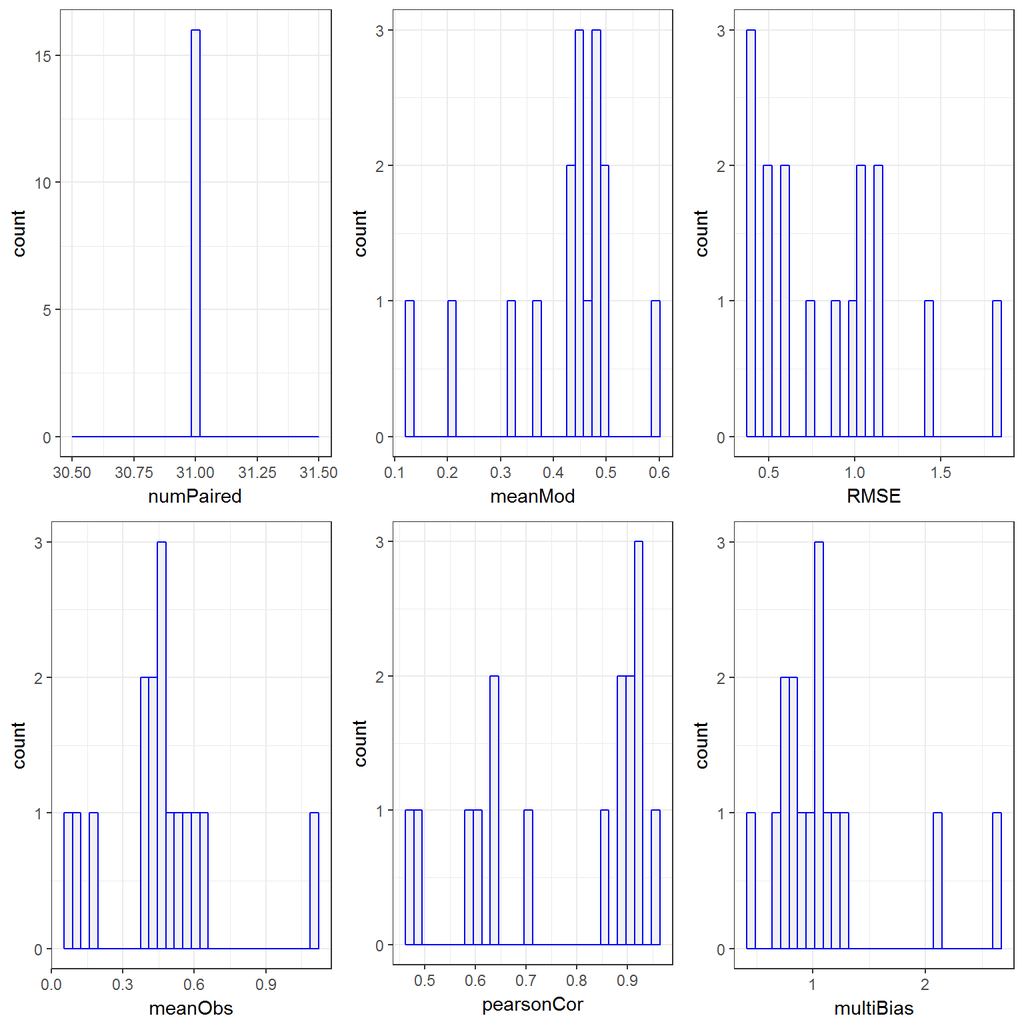

```r
> stat <- CalcStatCont(DT = common, obsCol = "dailyGhcn", modCol = "dailyPrcp" ,
+                      obsMissing = -999.9, groupBy = "statArg")
```

```r
> # CalcStatCont will return a list having two elements of stat and plotList.
> names(stat)
```

```
[1] "stat"     "plotList"
```

```r
> # Check the statistics
> stat$stat
```

```
       statArg numPaired    meanObs   meanMod pearsonCor      RMSE
1  USC00050848        31 0.50000000 0.4267882  0.8582963 0.9702969
2  USC00051186        31 0.17096774 0.3653501  0.9213103 0.4094233
3  USC00051681        31 1.11290323 0.4894894  0.6355658 1.8164975
4  USC00052223        31 0.55161290 0.4349553  0.9277122 0.7439128
5  USC00052790        31 0.63548387 0.5967560  0.6986647 1.4296532
6  USC00053116        31 0.12258065 0.1318100  0.4653354 0.5945282
7  USC00053261        31 0.46774194 0.3165000  0.8839877 1.0418398
8  USC00053387        31 0.61290323 0.4612764  0.5887336 1.1523853
9  USC00053629        31 0.37741935 0.4863579  0.9519768 0.3842942
10 USC00054293        31 0.39677419 0.4897431  0.4825698 1.0589073
11 USC00054762        31 0.45806452 0.4461394  0.9279037 0.4772271
12 USC00055402        31 0.56451613 0.4764994  0.8872483 0.9098565
13 USC00055984        31 0.44516129 0.4562135  0.9031227 0.5926413
14 USC00056816        31 0.41935484 0.4739974  0.6347046 1.1591130
```

[output cut: 19 more lines]

If the `groupBy` is `NULL` then it will return the overall stats for all the data and provide four informative plots.

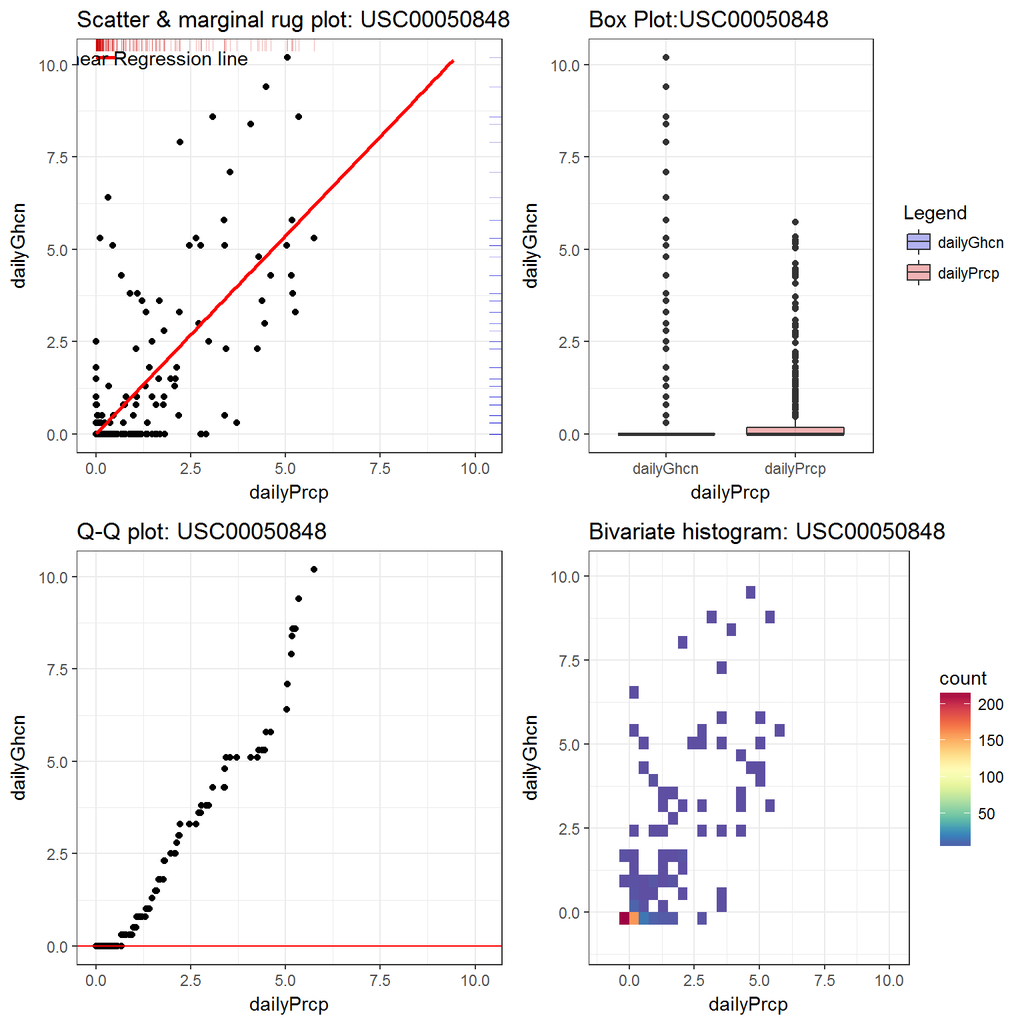

```r
> stat <- CalcStatCont(DT = common, obsCol = "dailyGhcn", modCol = "dailyPrcp", obsMissing = -999.9, title = common$statArg)
```

You can choose among the four plots by changing the `plot.list` argument.

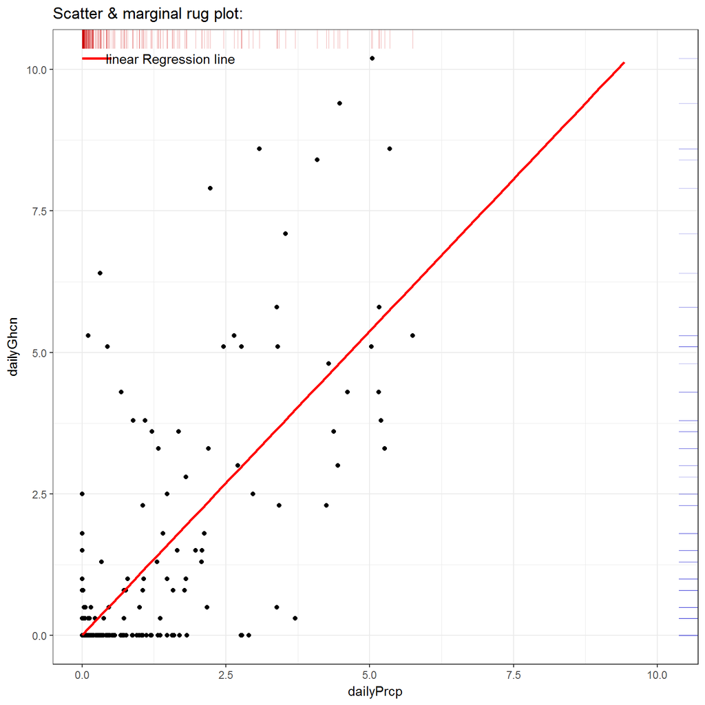

```r
> stat <- CalcStatCont(DT = common, obsCol = "dailyGhcn", modCol = "dailyPrcp" , obsMissing = -999.9, plot.list = "scatterPlot")
```

You can also calculate conditional statistics by defining the boundaries you are interested in. For example, here we calculate the statistics conditioned on the observation to be greater than 1 mm.

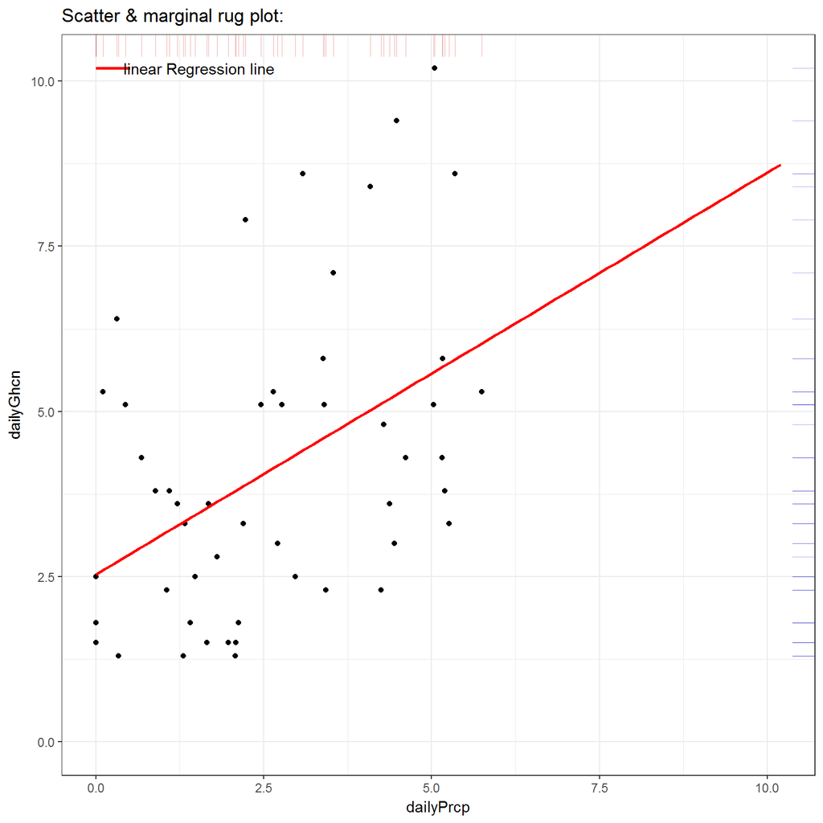

```r
> stat <- CalcStatCont(DT = common, obsCol = "dailyGhcn", modCol = "dailyPrcp" ,
+                      obsCondRange = c(1, Inf), plot.list = "scatterPlot")
```

```r
> stat$stat
```

```
  numPaired  meanObs  meanMod pearsonCor     RMSE multiBias
1        51 4.111765 2.594549  0.4620566 2.616446 0.6310061
```

## Calculate statistics over RFCs

Sometime the verification result at the gauge location is not desired and we want to find the performance of a model over a domain or polygon. If you want to calculate statistics over RFC’s, then use `GetRfc` function. One can find out a gauge (point) falls in which RFC using `GetRfc`. You simply feed a dataframe having at least two columns of `latitude` and `longitude` and this functions adds a column to a dataframe with RFC name.

```r
> # add rfc name
> sg <- GetRfc(sg)
>
> # check what is been added
> head(sg)
```

```
  country network stationID elevation state                           name
1      US       C  00050674    3448.2    CO BERTHOUD PASS
2      US       C  00050848    1671.5    CO BOULDER
3      US       C  00051186    3054.1    CO CABIN CREEK
4      US       C  00051681    2728.0    CO COAL CREEK CANYON
5      US       C  00051829    2895.6    CO CONIFER 8 W
6      US       C  00052223    1593.5    CO DENVER WATER DEPT
  GSNflag HCN.CRNflag WMOID     siteIds  we  sn reportTime   rfc longitude
1                           USC00050674 100 205        700 MBRFC -105.7833
2                 HCN       USC00050848 144 221        700 MBRFC -105.2667
3                           USC00051186 104 189        700 MBRFC -105.7089
4                           USC00051681 134 212        700 MBRFC -105.3847
5                           USC00051829 131 172        700 MBRFC -105.3631
6                           USC00052223 163 191        700 MBRFC -105.0083
  latitude
1  39.8000
2  39.9919
3  39.6553
4  39.8958
5  39.5250
6  39.7294
```

Now, add a column to the `common` data having the `rfc` information for each data. And calculate the statistics based on grouping by RFC.

```r
> # merge the common with the sg data.frame
> common <- merge(common,sg[, c("siteIds", "rfc")],
+                 by.x=c("statArg"),
+                 by.y=c("siteIds"))
>
> # calculate statistics using grouping by rfc
> stat <- CalcStatCont(DT = common, obsCol = "dailyGhcn", modCol = "dailyPrcp" ,
+                      groupBy = "rfc", obsMissing = -999.9, plot.it = FALSE)
>
> stat$stat
```

```
    rfc numPaired   meanObs   meanMod pearsonCor      RMSE multiBias
1 MBRFC       434 0.5101382 0.4554420  0.7628451 0.9891797 0.8927815
2 CBRFC        62 0.1016129 0.1715713  0.4930983 0.5038713 1.6884799
```

Here, the overall stats for each RFC (MBRFC and CBRFC in this case) is given.

## Calculate statistics over polygons

One can also calculate the statistics over any desired polygon shapefile. First, you need to use `GetPoly` function to find each point falls into which polygon. `GetPoly` takes a dataframe containing at least two fields of `latitude` and `longitude`, overlays the points using the `SpatialPolygonDataFrame` function and return the requested attributes from the polygon. You can use the available `SpatialPolygon*` loaded into memory or provide the address to the location of a polygon shapefile and the name of the shapefile. The `clipped_HUC6` shapefile is provided with the test case. The polygon extend is more than the Front Range case study.

```r
> # add HUC6 ids
> polygonAddress <- paste0(path.expand(fcPath), "/polygons")
> sg <- GetPoly (sg,  polygonAddress = polygonAddress,
+                polygonShapeFile = "clipped_huc6",
+                join="HUC6")
> # check what is been added
> head(sg)
```

```
  country network stationID elevation state                           name
1      US       C  00050674    3448.2    CO BERTHOUD PASS
2      US       C  00050848    1671.5    CO BOULDER
3      US       C  00051186    3054.1    CO CABIN CREEK
4      US       C  00051681    2728.0    CO COAL CREEK CANYON
5      US       C  00051829    2895.6    CO CONIFER 8 W
6      US       C  00052223    1593.5    CO DENVER WATER DEPT
  GSNflag HCN.CRNflag WMOID     siteIds  we  sn reportTime   rfc   HUC6
1                           USC00050674 100 205        700 MBRFC 101900
2                 HCN       USC00050848 144 221        700 MBRFC 101900
3                           USC00051186 104 189        700 MBRFC 101900
4                           USC00051681 134 212        700 MBRFC 101900
5                           USC00051829 131 172        700 MBRFC 101900
6                           USC00052223 163 191        700 MBRFC 101900
  longitude latitude
1 -105.7833  39.8000
2 -105.2667  39.9919
3 -105.7089  39.6553
4 -105.3847  39.8958
5 -105.3631  39.5250
6 -105.0083  39.7294
```

```r
> # merge the common data.frame with the sg data.frame
> common <- merge(common,sg[, c("siteIds","HUC6")],
+                                         by.x=c("statArg"),
+                                         by.y=c("siteIds"))
>
> # calculate statistics using grouping by HUC6
> stat <- CalcStatCont(DT = common, obsCol = "dailyGhcn", modCol = "dailyPrcp",
+                      obsMissing = -999.9, groupBy = "HUC6", plot.it = FALSE)
> print(stat$stat)
```

```
    HUC6 numPaired   meanObs   meanMod pearsonCor      RMSE multiBias
1 101900       434 0.5101382 0.4554420  0.7628451 0.9891797 0.8927815
2 140100        62 0.1016129 0.1715713  0.4930983 0.5038713 1.6884799
```

All the gages have fallen in two HUC6, and the overall stats for each of these hucs (101900, 140100) is given.

## Calculate categorical statistics

You can also calculate some of the categorical statistics using `CalcStatCategorical` function. It accepts both categorical variable and continuous ones. If the data is actually categorical, variable `category` should be defined. The elements in `category` will be used as `YES` and `NO` in contingency table. If the data is numeric, then a set of thresholds should be defined. Values exceeding the threshold would be flagged as `YES` and the values below the threshold are considered `NO`. You can choose from the available statistics by changing the `statList` argument. By default, it calculates the Hit Rate (H), False Alarm Ratio (FAR) and Critical Success Index (CSI). The grouping option is similar to `CalcStatCont`.

```r
> # calculate categorical statistics
> stat <- CalcStatCategorical(DT = common, obsCol = "dailyGhcn", modCol = "dailyPrcp",
+                             obsMissing = -999.9, groupBy = "rfc", threshold = c(1,5))
> print(stat)
```

```
    rfc threshold         H       FAR       CSI
1 MBRFC         1 0.8163265 0.3846154 0.5405405
2 CBRFC         1 0.5000000 0.5000000 0.3333333
3 MBRFC         5 0.2777778 0.3750000 0.2380952
4 CBRFC         5       NaN       NaN       NaN
```